# Sydney_water

Seshadhri S

2025-05-13

# Sydney Water Quality

This week we’re exploring the water quality of Sydney’s iconic beaches. The data is available at the New South Wales State Government Beachwatch website.

Beachwatch and our partners monitor water quality at swim sites to ensure that recreational water environments are managed as safely as possible so that as many people as possible can benefit from using the water.

Sydney beaches were in the news this summer with high rainfall causing concerns about the safety of the water.

The dataset this week includes both water quality and historical weather data from 1991 until 2025.

Has the water quality declined over this period? How does rainfall impact E-coli bacteria levels? Are some swimming sites particularly prone to high bacteria levels following rain? Thank you to Jen Richmond (R-Ladies Sydney) for curating this week’s dataset.

```r
# Using R
# Option 1: tidytuesdayR R package
## install.packages("tidytuesdayR")

tuesdata <- tidytuesdayR::tt_load('2025-05-20')
```

```
## ---- Compiling #TidyTuesday Information for 2025-05-20 ----
## --- There are 2 files available ---
##
##
## ── Downloading files ───────────────────────────────────────────────────────────
##
##   1 of 2: "water_quality.csv"
##   2 of 2: "weather.csv"
```

```r
## OR
tuesdata <- tidytuesdayR::tt_load(2025, week = 20)
```

```
## ---- Compiling #TidyTuesday Information for 2025-05-20 ----
## --- There are 2 files available ---
##
##
## ── Downloading files ───────────────────────────────────────────────────────────
##
##   1 of 2: "water_quality.csv"
##   2 of 2: "weather.csv"
```

```r
water_quality <- tuesdata$water_quality
weather <- tuesdata$weather

# Option 2: Read directly from GitHub

water_quality <- readr::read_csv('https://raw.githubusercontent.com/rfordatascience/tidytuesday/main/data/2025/2025-05-20/water_quality.csv')
weather <- readr::read_csv('https://raw.githubusercontent.com/rfordatascience/tidytuesday/main/data/2025/2025-05-20/weather.csv')
library(tidyverse)
library(lubridate)
library(tidygeocoder)
```

## Has the water quality declined over this period?

```r
table(water_quality$region)
```

```
##
## Northern Sydney Southern Sydney     Sydney City  Sydney Harbour  Western Sydney
##           43430           18770           18606           41770             954
```

```r
table(water_quality$council)
```

```
##
##                     Blue Mountains City Council
##                                             656
##                      City of Canada Bay Council
##                                            2663
##                         Hawkesbury City Council
##                                             247
##                              Inner West Council
##                                            1805
##                               Lane Cove Council
##                                            4594
##                        Mosman Municipal Council
##                                            6779
##                            North Sydney Council
##                                            1538
##                        Northern Beaches Council
##                                           54569
##                            Penrith City Council
##                                              51
##                           Randwick City Council
##                                           12137
##                        Sutherland Shire Council
##                                           18770
##                              The City of Sydney
##                                            1426
## The Council of the Municipality of Hunters Hill
##                                            2350
##                                Waverley Council
##                                            6469
##                         Willoughby City Council
##                                            1553
##                     Woollahra Municipal Council
##                                            7923
```

```r
table(water_quality$swim_site)
```

```
##
##                      Avalon Beach                    Balmoral Baths
##                              2064                              1552
##                  Bilarong Reserve                     Bilgola Beach
##                               643                              2080
##                      Boat Harbour                       Bondi Beach
##                              2495                              2128
##                      Bronte Beach                      Bungan Beach
##                              2200                              2080
##                    Cabarita Beach               Callan Park Seawall
##                              1405                               257
##                         Camp Cove                   Chinamans Beach
##                               398                              1258
##                    Chiswick Baths                   Clifton Gardens
##                              1258                              1499
##                     Clontarf Pool                    Clovelly Beach
##                              1554                              2151
##                    Collaroy Beach                      Coogee Beach
##                              2078                              2207
##                   Darling Harbour                  Davidson Reserve
##                              1426                              1492
##                  Dawn Fraser Pool                     Dee Why Beach
##                              1548                              2077
##                     Edwards Beach                     Elouera Beach
##                              1502                              2508
##                   Fairlight Beach                Forty Baskets Pool
##                              1378                              1503
##                  Freshwater Beach                Gordons Bay (East)
##                              2058                               698
##                  Greenhills Beach                   Greenwich Baths
##                              2485                              1558
##             Gurney Crescent Baths                Hayes Street Beach
##                              1373                              1538
## Henley Baths (Kelly Street Baths)                  Little Bay Beach
##                               803                              1333
##                 Little Manly Cove                Little Sirius Cove
##                              1501                               968
##                   Long Reef Beach                     Malabar Beach
##                              2048                              2142
##                        Manly Cove                    Maroubra Beach
```

[output cut: 26 more lines]

```
##                              2186                              2141
##                    Tambourine Bay                   Turimetta Beach
##                              1499                              1815
##                       Wanda Beach                  Warriewood Beach
##                              2507                              2077
##                       Watsons Bay      Wentworth Falls Lake - Beach
##                              1501                               183
##      Wentworth Falls Lake - Jetty                       Whale Beach
##                               191                              2082
##                     Windsor Beach                      Woodford Bay
##                               124                              1537
##                    Woolwich Baths                Yarramundi Reserve
##                              1547                               123
##  Yosemite Creek - Minnehaha Falls
##                               110
```

```r
water_quality_clean <- water_quality %>% filter(!is.na(enterococci_cfu_100ml))
class(water_quality$date)
```

```
## [1] "Date"
```

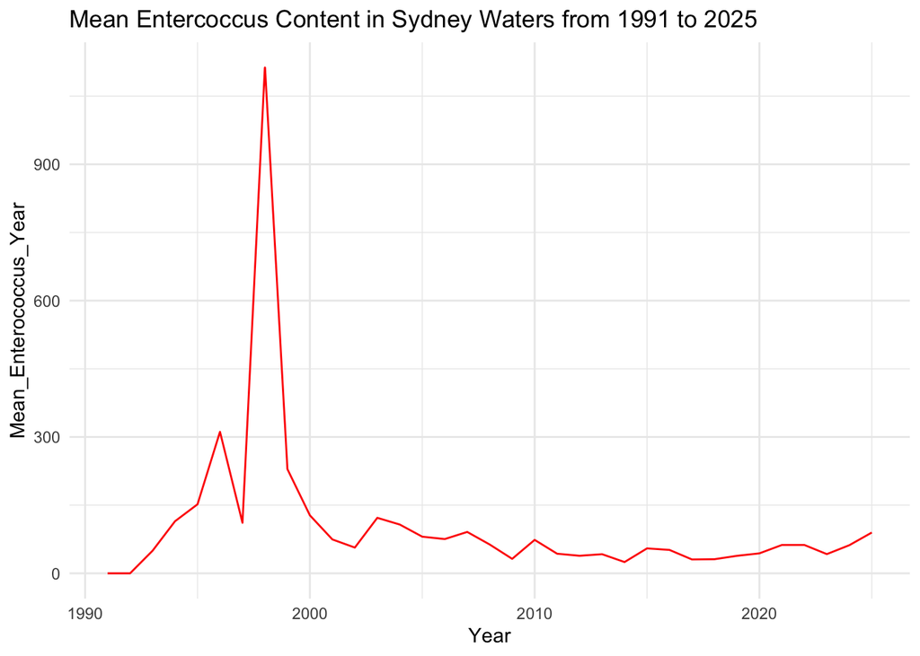

```r
water_quality_clean <- water_quality_clean %>% mutate(Year = year(date))
water_quality_summarised <- water_quality_clean %>% group_by(Year) %>% summarise(Mean_Enterococcus_Year = mean(enterococci_cfu_100ml))

ggplot(water_quality_summarised, aes(x = Year, y = Mean_Enterococcus_Year)) +
  geom_line(color = "red") +
  labs(title = "Mean Entercoccus Content in Sydney Waters from 1991 to 2025", xlab = "Year", ylab = "Mean Entercoccus Content") +
  theme_minimal()
```

```r
#Water quality by Swim site, council and region
# Region
mean_content_region <- water_quality_clean %>%
  group_by(region, Year) %>%
  summarise(mean_enterococcus = mean(enterococci_cfu_100ml, na.rm = TRUE)) %>%
  ungroup()
```

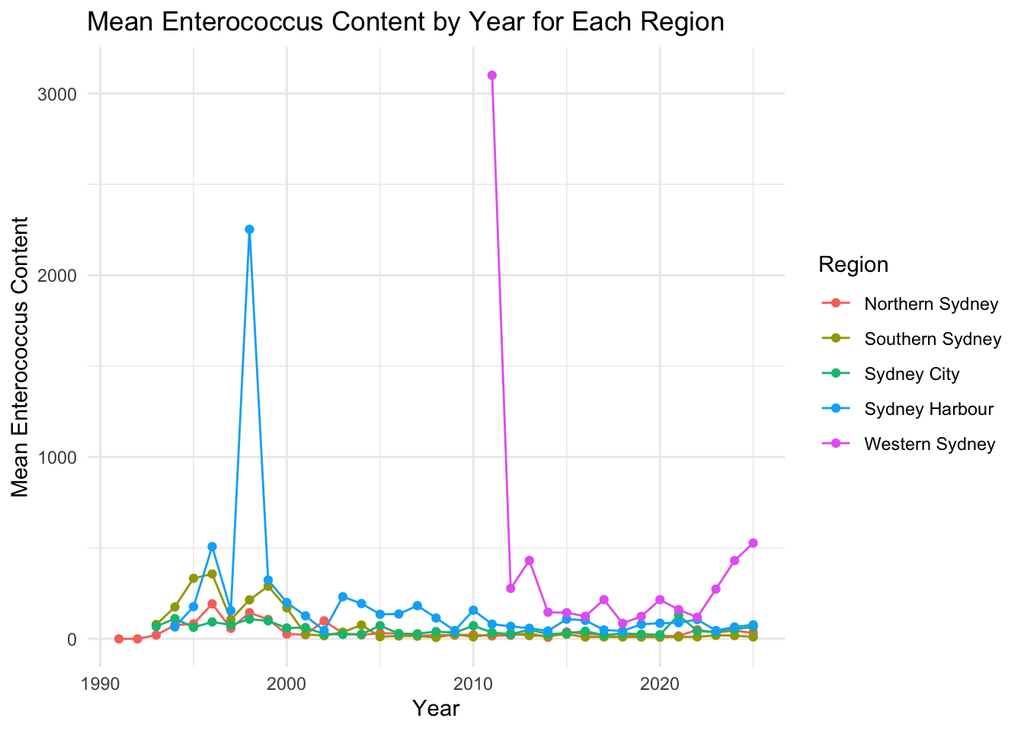

```r
ggplot(mean_content_region, aes(x = Year, y = mean_enterococcus, color = region)) +
  geom_line() +
  geom_point() +
  labs(title = "Mean Enterococcus Content by Year for Each Region",
       x = "Year",
       y = "Mean Enterococcus Content",
       color = "Region") +
  theme_minimal()
```

```r
# Council

mean_content_council <- water_quality_clean %>%
  group_by(council, Year) %>%
  summarise(mean_enterococcus = mean(enterococci_cfu_100ml, na.rm = TRUE)) %>%
  ungroup()
```

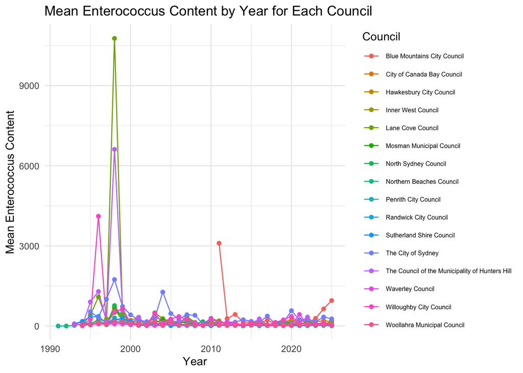

```r
ggplot(mean_content_council, aes(x = Year, y = mean_enterococcus, color = council)) +
  geom_line() +
  geom_point() +
  labs(title = "Mean Enterococcus Content by Year for Each Council",
       x = "Year",
       y = "Mean Enterococcus Content",
       color = "Council") +
  theme_minimal() +
  theme(legend.text = element_text(size = 6))
```

## How does rainfall impact E-coli bacteria levels?

```r
rainfall <- weather %>% select(date, precipitation_mm)
rainfall <- rainfall %>% mutate(Year = year(date))
rainfall <- rainfall %>% group_by(Year) %>% summarise(Mean_Rainfall = mean(precipitation_mm))

rainfall_ecoli_merged <- merge(rainfall, water_quality_summarised, by = "Year")
cor(rainfall_ecoli_merged$Mean_Rainfall, rainfall_ecoli_merged$Mean_Enterococcus_Year, method = "spearman")
```

```
## [1] -0.03039429
```

```r
weather_places <- weather %>%
  reverse_geocode(lat = latitude, long = longitude, method = "osm")
```

```
## Passing 1 coordinate to the Nominatim single coordinate geocoder
```

```
## Query completed in: 1.1 seconds
```

I thought the latitude and longitude were different for each measurement. Turns out they aren’t so couldn’t go further. At least I learnt about tidygeocoder

There’s also no real correlation vbetween rainfall and bacteria levels. I didn’t really feel like doing another line plot if there isn’t a massive correlation over time.

## Are some swimming sites particularly prone to high bacteria levels following rain?

Didn’t have time to do this